# Exercise Prediction Model

Michael Coote

2/3/2019

## Objective

To model sensor data taken during weight lifting excercise to determine the quality of the movement.

## Load and Clean Data

From the Human Activity Recognition (HAR) research the Weight Lifting Exercises (WLE) dataset was used

1. The training data: https://d396qusza40orc.cloudfront.net/predmachlearn/pml-training.csv
2. The test data: https://d396qusza40orc.cloudfront.net/predmachlearn/pml-testing.csv

```r
file_train <-
  "https://d396qusza40orc.cloudfront.net/predmachlearn/pml-training.csv"
file_test <-
  "https://d396qusza40orc.cloudfront.net/predmachlearn/pml-testing.csv"
# check file to see if it is truly a csv
readLines(file_train, n = 2)
pml_train <-
  read.csv(file_train, na.strings = c("NA", "#DIV/0!"))
pml_test <-
  read.csv(file_test, na.strings = c("NA", "#DIV/0!"))
```

## Explore and Clean Data

### Variables and Observations

```r
pml_train <- as_tibble(pml_train)
pml_test <- as_tibble(pml_test)
```

- The train dataset has 160 variables with 19622 observations
- The test dataset has 160 variables with 20 observations

```r
pml_train_cln <- pml_train %>%
  select(matches("belt|forearm|arm|dumbbell"), classe)
pml_test_cln <- pml_test %>%
  select(matches("belt|forearm|arm|dumbbell"))
```

### Outcome Counts

Counts of each class: 5580, 3797, 3422, 3216, 3607 (A - E, respectively)

### Remove Sparse Data

Sparsely - greater than half the obsrvations - populated variables are removed from the set.

```r
# omit variables with many NA observations
r <- nrow(pml_train_cln)
pml_train_cln <- pml_train_cln %>% select_if(~mean(is.na(.)) < 0.5)
cols_pml <- names(pml_train_cln)[-(ncol(pml_train_cln))]
pml_test_cln <- pml_test_cln %>% select(cols_pml)
```

## Split Training Set

The training dataset (set with known outcomes) is split for later model verification (25% test reserve).

```r
inTrain <- as.integer(createDataPartition(y = pml_train_cln$classe,
                               p = 0.75, list = FALSE))
pml_train_cln_train <- pml_train_cln[inTrain,]
pml_train_cln_test <- pml_train_cln[-inTrain,]
```

- 14718 observations will be used for training the model
- 4904 observations will be used for testing the model

## Decision Tree Model

The model is creating using an rpart decision tree method from the caret package.

### Model Creation

```r
set.seed(123)
modelPML <- train(classe ~ ., data = pml_train_cln_train, method = "rpart")
```

Testing predictors determined using a Principal Component Analysis (PCA). The model is then trained on the PCA using the same decision tree method.

```r
preProcPML <- preProcess(pml_train_cln_train[, cols_pml],
                         method = "pca", thresh = 0.8)
pml_train_cln_PCA <- predict(preProcPML, pml_train_cln_train)
modelPML_PCA <- train(classe ~ ., data = pml_train_cln_PCA, method = "rpart")
```

### Model Verification

View a plot of the models to ensure the decisions make sense.

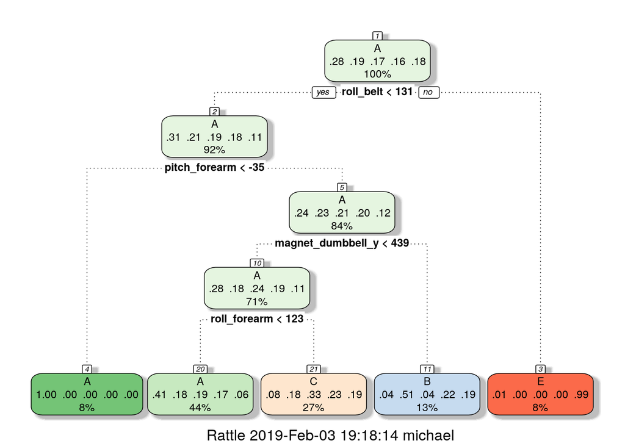

```r
fancyRpartPlot(modelPML$finalModel)
```

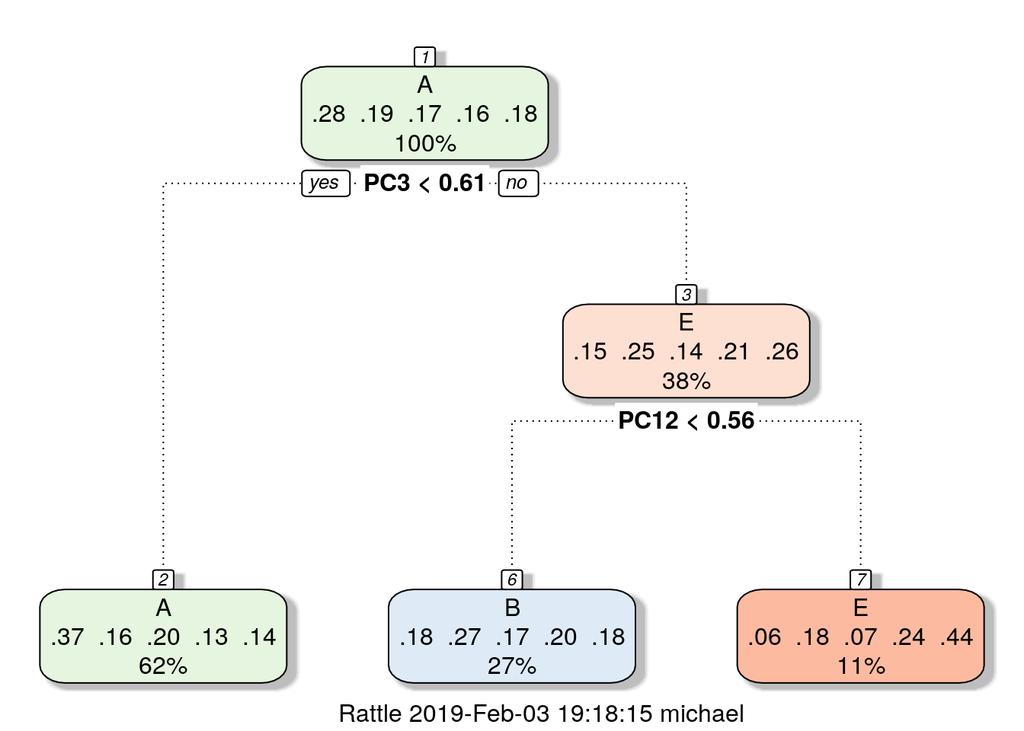

```r
fancyRpartPlot(modelPML_PCA$finalModel)
```

### In Sample Error

Show a confussion matrix on a prediction of the training dataset

```r
trainPML_predict <- predict(modelPML, pml_train_cln_train)
cm_train <- confusionMatrix(trainPML_predict, pml_train_cln_train$classe)

trainPML_PCA_predict <- predict(modelPML_PCA, pml_train_cln_PCA)
cm_train_pca <- confusionMatrix(trainPML_PCA_predict, pml_train_cln_PCA$classe)
```

The decision tree model has an overall accuracy of 0.4942248. While the model using PCA has an overall accuracy of 0.3504552. Using PCA doesn’t show any advantage.

### Out of Sample Error

```r
trainPML_test_predict <- predict(modelPML, pml_train_cln_test)
cm_train_test <- confusionMatrix(trainPML_test_predict,
                                 pml_train_cln_test$classe)
```

The cases in the training set which were reserved for testing confirm an overall model accuracy of 0.4989804. However, the cross tabulatiom of the results shows classe D can not be predicted.

```r
cm_train_test$table %>% kable %>% kable_styling(full_width = F)
```

|  | A | B | C | D | E |
| --- | --- | --- | --- | --- | --- |
| A | 1266 | 409 | 385 | 351 | 122 |
| B | 18 | 308 | 28 | 144 | 125 |
| C | 109 | 232 | 442 | 309 | 223 |
| D | 0 | 0 | 0 | 0 | 0 |
| E | 2 | 0 | 0 | 0 | 431 |

### Train Prediction

```r
testPML_predict <- predict(modelPML, newdata = pml_test_cln)
```

```r
cm_test <- confusionMatrix(testPML_predict, testPML_predict)
cm_test$overall %>% t %>% kable %>% kable_styling(full_width = F)
```

| Accuracy | Kappa | AccuracyLower | AccuracyUpper | AccuracyNull | AccuracyPValue | McnemarPValue |
| --- | --- | --- | --- | --- | --- | --- |
| 1 | 1 | 0.8315665 | 1 | 0.55 | 6.4e-06 | NaN |

## Random Forest Model

Next, we will attempt to classify using a Random Forest Model, reducing the impact of strong predictors, which may be limiting our ability to predic classe D cases. It may also improve accuracy by producing multiple trees and votes for the best.

### Model Creation

```r
modelPML_rf <- train(classe ~ ., data = pml_train_cln_train, method = "rf")
```

### Model Verification

The Random Forest Model showed excellent accuracy.

```r
modelPML_rf
```

```
Random Forest

14718 samples
   52 predictor
    5 classes: 'A', 'B', 'C', 'D', 'E'

No pre-processing
Resampling: Bootstrapped (25 reps)
Summary of sample sizes: 14718, 14718, 14718, 14718, 14718, 14718, ...
Resampling results across tuning parameters:

  mtry  Accuracy   Kappa
   2    0.9898457  0.9871515
  27    0.9900977  0.9874703
  52    0.9821635  0.9774297

Accuracy was used to select the optimal model using the largest value.
The final value used for the model was mtry = 27.
```

### In Sample Error

Show a confussion matrix on a prediction of the training dataset

```r
trainPML_predict_rf <- predict(modelPML_rf, pml_train_cln_train)
cm_train_rf <- confusionMatrix(trainPML_predict_rf, pml_train_cln_train$classe)
```

The Random Forest model has an overall accuracy of 1, or perfect!

### Out of Sample Error

```r
trainPML_test_predict_rf <- predict(modelPML_rf, pml_train_cln_test)
cm_train_test_rf <- confusionMatrix(trainPML_test_predict_rf,
                                    pml_train_cln_test$classe)
```

The cases in the training set which were reserved for testing confirm an overall model accuracy of 0.9918434.

```r
cm_train_test_rf$table %>% kable %>% kable_styling(full_width = F)
```

|  | A | B | C | D | E |
| --- | --- | --- | --- | --- | --- |
| A | 1392 | 2 | 0 | 0 | 0 |
| B | 2 | 945 | 2 | 0 | 1 |
| C | 0 | 2 | 843 | 10 | 4 |
| D | 0 | 0 | 10 | 792 | 4 |
| E | 1 | 0 | 0 | 2 | 892 |

### Train Prediction

Perform predictions on the test set using the Random Forest model and display results for the 20 test cases.

```r
testPML_predict_rf <- predict(modelPML_rf, newdata = pml_test_cln)
testPML_predict_rf %>% t %>% kable %>% kable_styling(full_width = F)
```

| B | A | B | A | A | E | D | B | A | A | B | C | B | A | E | E | A | B | B | B |
| --- | --- | --- | --- | --- | --- | --- | --- | --- | --- | --- | --- | --- | --- | --- | --- | --- | --- | --- | --- |

Use a confussion matrix to illustrate the Classe assignments.

```r
cm_test_rf <- confusionMatrix(testPML_predict_rf, testPML_predict_rf)
cm_test_rf$table %>% kable %>% kable_styling(full_width = F)
```

|  | A | B | C | D | E |
| --- | --- | --- | --- | --- | --- |
| A | 7 | 0 | 0 | 0 | 0 |
| B | 0 | 8 | 0 | 0 | 0 |
| C | 0 | 0 | 1 | 0 | 0 |
| D | 0 | 0 | 0 | 1 | 0 |
| E | 0 | 0 | 0 | 0 | 3 |

Note how all classes are represented.